# Project Report

## Project Objectives

Our project objective is to predict the trend and the exact stock price of a company from January 1, 2019 to March 31, 2019 to two groups of people, which are potential stakeholders and current stakeholders. Our potential stakeholders are investors and speculators. Whereas our current stakeholders are corporate management, shareholders and employees.

In order to do so, we chose three companies we interested within different industries, which are Apple, Disney, and Ford. We found the best model for our main target company and tested the best model to the other two companies under different industries to check if it is universally applicable. In the end, we generated stock price trend in graphs that are easily readable to our stakeholders and exact stock price of a day. Besides, to better predict the price, we introduced natural language processing and sentiment analysis based on news so that our stakeholders can used to conduct more insightful analysis.

## Instruction of Stage

Part 1: Using stock historical data

- Step1: Data process and preparation
  - Combining data set. Combine Disney stock historical data with market indexes, aligned with date.
  - Visualization. Draw a line plot of historical data to have an intuition and basic image of the trend and fluctuation.
  - Calculating derived variables to improve prediction.
- Step 2: Model test
  - Experimented neural network, ARIMA, LSTM and SVM models to predict the trend and exact price in future.
- Step 3: Applied best model to other companies to check whether it is universally applicable
  - As the SVM model hit the best prediction result, we choose it as our prediction model and applied this model to other two companies, Ford and Apple, to check whether it is also universally applicable in other industries.

Part 2: Sentiment analysis on social media and news

- Step 4: Scraping text from tweet and Reuters news
  - Scraping data from Twitter. We applied a Twitter Developer App and took advantage of Twitter API to scrape Tweets. More than 2000 pieces of Tweet are collected.
  - Scraping data from Reuters. We chose Reuters as our target news portal and scraped more than 200 news articles on Apple company. These articles dates from August, 2018 to the most recent days.
- Step 5: Text cleaning and processing
  - Removing punctuation.
  - Tokenization.
  - Customizing stopword list and removing stopwords.
  - Stemming and lemmatization.
  - Testing quality of text cleaning and repeat above steps.
- Step 6: Word frequency count and visualization
  - Top 20 words frequency count
  - Word frequency line chart and word cloud
- Step 7: Sentiment analysis
  - Date extracting. Using regular expression to extract publishing date and convert them into timestamp format.
  - Sentiment analysis. Using ‘nltk’ package to do sentiment analysis
- Step 8: Combining sentiment analysis with stock price to check its influence.
  - Calculate correlation.
  - Visualization. Draw heatmap and line&bar plot to its correlation.

## Data Description and Source

Our data mainly concluded into two parts:

- The first part is historical stock data from Yahoo Finance, which dates from January 1, 2014 to March 31, 2019. Also, we included some market index to reflect the market prosperity. Based on these data sets, we calculated some variables to improve our analysis, including moving average, exponential average and RSI.
- The second part is text data we scraped from social media, Twitter (using Twitter API), and news portal, Reuters. The details will be shown in codes below. The scraped result and text data we got included more than 2000 Tweets and more than 200 news. We stored the tweets into .csv file, includes user name, text, and time stamp. And news content is stored in .txt file, with a .csv file to store the title and time stamp of each news.

The details of each variables are shown below:

### Variables from Yahoo Finance:

Date: The trading date

Open: Opening price on that day

High: The highest price reached on that day

Low: The lowest price reached on that day

Close: Closing price on that day

Volume: The number of shares traded on that day

Market Index: Index based on Date

S&P 500: an American stock market index based on the market capitalizations of 500 large companies

DJI: a stock market index that indicates the value of 30 large, publicly owned companies

NASDAQ: a stock market index of the common stocks and similar securities listed on the NASDAQ stock market

### Variables from Our Calculation:

Moving Average(5 days, 10 days & 20 days): Three calculation fields based on Date. It is a calculation to analyze data points by creating a series of average of 5 days, 10 days & 20 days of the full data set.

Moving average 5 days

Moving average 10 days

Moving average 20 days

Exponential moving average: A calculation fields based on Date. It is a weighted moving average that gives weighting to recent price data.

Relative Strength Index (RSI): A calculation fields based on Date. It is an indicator that measures the magnitude of recent price changes to evaluate overbought or oversold conditions. (14 days)

### Variables from Twitter:

User: the user’s screen name

Text: the text or content of this tweet

Time: the timestamp of this tweet or when the tweet is published

### Variables from Reuters:

ID: the ID of news article, act as an index to find its content .txt file

Title: the title of news article

Time: the timestamp of news article, or when the article is published

## Data Process

Historical data

- Combine data sets. Combine target company data with market indexes, aligned with date.
- Transform: moving average, exponential average and RSI
- Transform: Close-1 to Close-20. Add last 20 days close price to the variables by using a for loop and df.shift().
- Scale: using preprocessing.StandardScaler() or MinMaxScaler() to scale the dataset except dependent variable--Close
- Split dataset into training and test.
- Visualization: Draw a line plot to show its trend and fluctuation.

Sentiment analysis based on news title

After reading the csv file from the local, the data frame has some cleaning tasks need to be done as following:

- Firstly, we deleted the first column which only shows the indexes of the news.
- To get the exact date from the original data, e.g. March 22, 2019 / 6:11 AM / a month ago. We used the re.match with the pattern '(\w+\s\d+[,]\s\d{4})' to get the format: March 22,2019. Then replace the white space and comma with ’-’ and transform the whole column using pd.to_datetime(news.Date, format='%B-%d-%Y'). Finally, we got 2019-3-22.
- For news which are duplicate in the data frame, we deleted them through command news.drop_duplicates(keep = False, inplace = True). For dates which have more than one news, we grouped them by date and calculate the average sentiment score.
- We labeled the news title 1 as positive when its sentiment score is larger than 0.2, similarly, -1 as negative when sentiment score is smaller than -0.2. Otherwise, we labeled it 0 as neutral.
- To find out the impact of news on the stock price at that day, we checked the date when both news breaks and the stock market opens.

Text processing based on news content

The scraped news contents from Reuters are in text format and saved in a folder. To further process the data we conducted the following procedures:

- We used a loop to read all the text files in one folder into a list of lists of string. Each string represented content of a text file in the folder.
- We used list(itertools.chain.from_iterable()) to iterate the list of lists of string to a list of strings. Then, we looped through the list to convert the list of strings to lowercase strings and ready for our cleaning phase.
- After we printed out the string, we realized there are many unnecessary punctuations and existing URLs included, such as \x93, \'b\' and URL. We used replace() and re.sub() to remove all unnecessary punctuations.
- To break the string into words, we tokenized the string using word_tokenize() and filtered the stopwords using stopwords.words('english').
- To format the words into the most popular format so that we can count the frequency of them in later analysis, we stemmed and lemmatized the words using PorterStemmer() and WordNetLemmatizer()
- We count the top 20 words frequency to test to quality of data cleaning. However, there are not only many unnecessary punctuations exist again, but also unnecessary words that have high frequency exist. The unnecessary punctuations are caused by the tokenization of the URLs, and the unnecessary words are due to the news content itself. For example, there is ‘(reuters)’ signature exists for each Reuters news, which are unnecessary and caused high frequency. Another example is ‘stephen’ and ‘nellis’. Stephen Nellis is the reporters of Reuters that specifically reports Apple news, but this name is unnecessary for our analysis. Therefore, we went back and forth many times from removing punctuations to updating and filtering stopwords to exclude these unnecessary and meaningless punctuations and words until the data has been well cleaned.

## Data Analysis

**ARIMA**

Autoregressive Integrated Moving Average Model (ARIMA) is a model usually used in time series forecasting. As stock prices may have some relationship with its past data, ARIMA should be a model fit our problem. We took 5-year historical data as training data to fit our model. During the adjustment of the model, we figured out there is very weak seasonality exists in this data set so we removed seasonality feature from this model. However, this might not be the case as we test the model in the other two companies in the future. After testing the model with 90-day testing data, the best model we got for ARIMA is ARIMA(0,1,0) with mse of 2.81.

**Neural Network**

**Long short-term memory (LSTM)**

LSTM are used in sequence prediction problems because LSTM can store past information that is important and forget the unimportant information. We prepared the data and fit the 5-year training data with LSTM model, and tested the model with 90-day testing data to get the test MSE of 1.91 and Loss of 0.0054. Finally, we plot the actual and predicted trend from January 1, 2019 to today to see the performance.

**SVC**

To predict whether the stock price is up or down in one day, all three accuracies of SVC model with different kernels reach more than 95%. Based on our prediction, the return of the disney stock in first three months in 2019 is nearly 20%, not considering the trade costs, while the stock price itself fluctuates between -5% and 5%.

**SVR**

From the figure we can see that the predicted results fit the real close price very well. The model captures nearly all the trends of market change, and can also get a return of 20%. By comparing the two lines in the figure, whenever the stock is going to be down, the model will not buy in the stock and the strategy line is flatten. Thus, the ROI keeps increasing when the stock is going to be up and remains steady when it will be down in three months.

**Sentiment analysis**

We find that there is no significant correlation between the News sentiment score and the volatility of the stock price. During 2019-11 to 2019-04, Apple stock has risen a lot, while there is much more negative news than positive news during this period.

**Text Processing based on News Content**

The words frequency figure shows the visualized frequency of the top 10 most common words in Reuters news content from August 2018 to the latest, which are apple, iphone, company, inc, qualcomm, service, year, sale, chip and percent. The word cloud gives us more information about the popular words in the news, like China, Amazon, App, TV and etc.

## Conclusion of Findings and Application

For breaking news, there is no significant correlation between the sentiment score and the volatility of the stock, which is somehow contrary to the common sense. Sometimes, it is caused by the market panic and the investors should not be emotional.

Limitations:

- For SVM model itself, if we increase the parameter C in SVM.SVC, penalty parameter C of the error term, the accuracy will increase but also require a longer runtime.
- In the model, we use the past 20 days close price and one day’s open price to predict the close price. We can make prediction only if we know the open price for that day after the market opens and cannot use it for a long-term investment.
- To calculate the return, we make the assumption that we can make investment decision as soon as we know the open price and apply it to our model. And also, there is no trading cost when we buy in the stock and sell it at the end of the day.

## Reference

Account, A. (n.d.). Apple (@Apple). Retrieved May 12, 2019, from https://twitter.com/apple?lang=en

Apple Inc (AAPL.OQ) News. (n.d.). Retrieved May 12, 2019, from https://www.reuters.com/finance/stocks/company-news/AAPL.OQ

Yahoo Finance - Business Finance, Stock Market, Quotes, News. (n.d.). Retrieved March 31, 2019, from https://finance.yahoo.com/

## Part 1 Find the Best Model

```python
import pandas as pd
import numpy as np
import matplotlib.pyplot as plt
```

```python
#change working directory
import os
os.chdir("C:/Users/86187/Desktop/758X Python/project/DA")
```

```python
# to import data
pd.options.mode.chained_assignment = None
Disney=pd.read_csv("DIS.csv")
#DJI=pd.read_csv("DJI.csv")
#NASDAQ=pd.read_csv("IXIC.csv")
#SP=pd.read_csv("GSPC.csv")
Disney['Date']=pd.to_datetime(Disney.Date, format='%Y-%m-%d')
Disney.set_index('Date',inplace = True)
Disney.head(10)
```

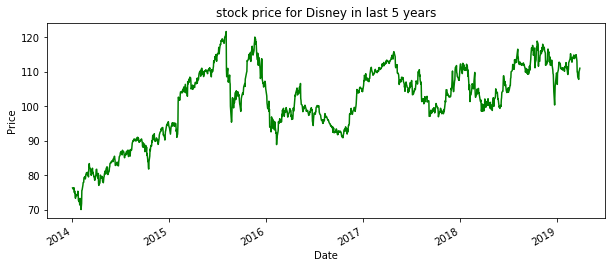

```python
#show the data
Disney["Close"].plot(color = 'green',figsize=(10,4))
plt.xlabel('Date')
plt.ylabel('Price')
plt.title('stock price for Disney in last 5 years')
plt.show()
```

```python
#Calculating moving average 5,10, 20 days
Disney["5 MA"]=Disney["Close"].rolling(5).sum()/5
Disney["10 MA"]=Disney["Close"].rolling(10).sum()/10
Disney["20 MA"]=Disney["Close"].rolling(20).sum()/20
Disney.head(10)
```

| Date | Open | High | Low | Close | Adj Close | Volume | 5 MA | 10 MA | 20 MA |
| --- | --- | --- | --- | --- | --- | --- | --- | --- | --- |
| 2014-01-02 | 76.040001 | 76.500000 | 75.900002 | 76.269997 | 71.050354 | 5200900 | NaN | NaN | NaN |
| 2014-01-03 | 76.300003 | 76.699997 | 76.010002 | 76.110001 | 70.901306 | 4060700 | NaN | NaN | NaN |
| 2014-01-06 | 76.529999 | 76.839996 | 75.489998 | 75.820000 | 70.631157 | 6816200 | NaN | NaN | NaN |
| 2014-01-07 | 76.120003 | 76.699997 | 75.900002 | 76.339996 | 71.115562 | 4494900 | NaN | NaN | NaN |
| 2014-01-08 | 76.129997 | 76.279999 | 74.809998 | 75.220001 | 70.072197 | 10900300 | 75.951999 | NaN | NaN |
| 2014-01-09 | 75.459999 | 75.459999 | 74.320000 | 74.900002 | 69.774109 | 8052900 | 75.678000 | NaN | NaN |
| 2014-01-10 | 75.080002 | 75.510002 | 74.559998 | 75.389999 | 70.230576 | 6219000 | 75.534000 | NaN | NaN |
| 2014-01-13 | 74.900002 | 75.129997 | 73.050003 | 73.269997 | 68.255653 | 8232800 | 75.023999 | NaN | NaN |
| 2014-01-14 | 73.709999 | 74.580002 | 73.290001 | 74.449997 | 69.354889 | 5996500 | 74.645999 | NaN | NaN |
| 2014-01-15 | 74.300003 | 75.099998 | 74.250000 | 74.279999 | 69.196533 | 7283900 | 74.457999 | 75.204999 | NaN |

##### Moving Average

As Adam Hayes puts, a moving average (MA) is a widely used indicator in technical analysis that helps smooth out price action by filtering out the “noise” from random short-term price fluctuations. It is a trend-following, or lagging, indicator because it is based on past prices.

So, we introduce moving average to our model, to filter out noise in daily prices, which is a common phenomenon for stock maket.

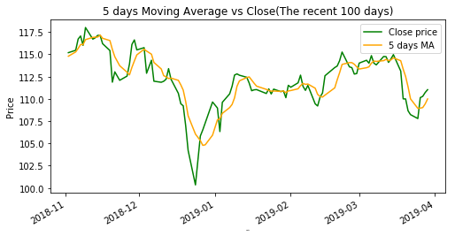

```python
# to slice the recent 100 days
Disney['Close'][-100:].plot(figsize=(8,4),color='green')
Disney['5 MA'][-100:].plot(color='orange')
# to draw the plot
plt.xlabel('Date',fontsize = 2)
plt.ylabel('Price')
plt.title('5 days Moving Average vs Close(The recent 100 days)')
plt.legend(('Close price','5 days MA'))
plt.show()
```

From the graph, we noticed that the 5 days moving average line is much more smoothy.

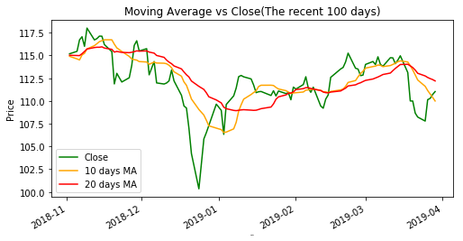

```python
# to slice the recent 100 days
Disney['Close'][-100:].plot(figsize=(8,4),color='green')
Disney['10 MA'][-100:].plot(color='orange')
Disney['20 MA'][-100:].plot(color='red')
# to draw the plot
plt.xlabel('Date',fontsize = 2)
plt.ylabel('Price')
plt.title('Moving Average vs Close(The recent 100 days)')
plt.legend(('Close','10 days MA','20 days MA'))
plt.show()
```

10 days and 20 days Moving average is even more smmooth, it filter out some 'noises' in a short term.

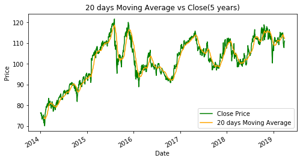

```python
Disney['Close'].plot(figsize=(8,4),color='green')
Disney['20 MA'].plot(color='orange')
plt.xlabel('Date')
plt.ylabel('Price')
plt.title('20 days Moving Average vs Close(5 years)')
plt.legend(('Close Price','20 days Moving Average'))
plt.show()
```

When it comes to a five-year duration, the effect of 20 days moving average is small. Moving average is rather close to the price itself.

##### Expoentional Moving Average

According to Inverstopedia, exponential moving average (EMA) is a type of moving average (MA) that places a greater weight and significance on the most recent data points. The exponential moving average is also referred to as the exponentially weighted moving average.

So, we also inluded EMA in our model, to attach more importance on recent prices.

```python
def EMA(values, window):
    """to calculate exponential mobing average"""
    weights = np.exp(np.linspace(-1., 0., window))
    weights /= weights.sum()
    a =  np.convolve(values, weights, mode='full')[:len(values)]
    a[:window] = a[window]
    return a
```

```python
#Calculating Exponential Moving Average
Disney["EMA"]=EMA(Disney['Close'],5)
Disney.head(10)
```

| Date | Open | High | Low | Close | Adj Close | Volume | 5 MA | 10 MA | 20 MA | EMA |
| --- | --- | --- | --- | --- | --- | --- | --- | --- | --- | --- |
| 2014-01-02 | 76.040001 | 76.500000 | 75.900002 | 76.269997 | 71.050354 | 5200900 | NaN | NaN | NaN | 75.814893 |
| 2014-01-03 | 76.300003 | 76.699997 | 76.010002 | 76.110001 | 70.901306 | 4060700 | NaN | NaN | NaN | 75.814893 |
| 2014-01-06 | 76.529999 | 76.839996 | 75.489998 | 75.820000 | 70.631157 | 6816200 | NaN | NaN | NaN | 75.814893 |
| 2014-01-07 | 76.120003 | 76.699997 | 75.900002 | 76.339996 | 71.115562 | 4494900 | NaN | NaN | NaN | 75.814893 |
| 2014-01-08 | 76.129997 | 76.279999 | 74.809998 | 75.220001 | 70.072197 | 10900300 | 75.951999 | NaN | NaN | 75.814893 |
| 2014-01-09 | 75.459999 | 75.459999 | 74.320000 | 74.900002 | 69.774109 | 8052900 | 75.678000 | NaN | NaN | 75.814893 |
| 2014-01-10 | 75.080002 | 75.510002 | 74.559998 | 75.389999 | 70.230576 | 6219000 | 75.534000 | NaN | NaN | 75.648958 |
| 2014-01-13 | 74.900002 | 75.129997 | 73.050003 | 73.269997 | 68.255653 | 8232800 | 75.023999 | NaN | NaN | 75.309548 |
| 2014-01-14 | 73.709999 | 74.580002 | 73.290001 | 74.449997 | 69.354889 | 5996500 | 74.645999 | NaN | NaN | 74.801319 |
| 2014-01-15 | 74.300003 | 75.099998 | 74.250000 | 74.279999 | 69.196533 | 7283900 | 74.457999 | 75.204999 | NaN | 74.575195 |

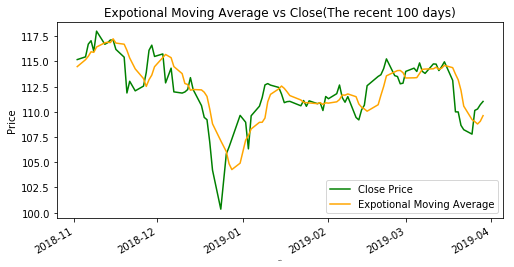

```python
Disney['Close'][-100:].plot(figsize=(8,4),color='green')
Disney['EMA'][-100:].plot(color='orange')
# to draw the plot
plt.xlabel('Date',fontsize = 2)
plt.ylabel('Price')
plt.title('Expotional Moving Average vs Close(The recent 100 days)')
plt.legend(('Close Price','Expotional Moving Average'))
plt.show()
```

```python
#Calculating RSI
def RSI(series, period = 14):
    u = series * 0
    d = u.copy()
    u[series > 0] = series[series > 0]
    d[series < 0] = -series[series < 0]
    u[u.index[period-1]] = np.mean( u[:period] ) #first value is sum of avg gains
    u = u.drop(u.index[:(period-1)])
    d[d.index[period-1]] = np.mean( d[:period] ) #first value is sum of avg losses
    d = d.drop(d.index[:(period-1)])
    #
    rs = pd.DataFrame.ewm(u, com=period-1, adjust=False).mean() / pd.DataFrame.ewm(d, com=period-1, adjust=False).mean()
    rsi = 100 - 100 / (1 + rs)
    return rsi
```

```python
close = Disney['Adj Close']
# Get the difference in price from previous step
delta = close.diff()
delta = delta[1:]
Disney['RSI'] = RSI(delta)
Disney.head(15)
```

| Date | Open | High | Low | Close | Adj Close | Volume | 5 MA | 10 MA | 20 MA | EMA | RSI |
| --- | --- | --- | --- | --- | --- | --- | --- | --- | --- | --- | --- |
| 2014-01-02 | 76.040001 | 76.500000 | 75.900002 | 76.269997 | 71.050354 | 5200900 | NaN | NaN | NaN | 75.814893 | NaN |
| 2014-01-03 | 76.300003 | 76.699997 | 76.010002 | 76.110001 | 70.901306 | 4060700 | NaN | NaN | NaN | 75.814893 | NaN |
| 2014-01-06 | 76.529999 | 76.839996 | 75.489998 | 75.820000 | 70.631157 | 6816200 | NaN | NaN | NaN | 75.814893 | NaN |
| 2014-01-07 | 76.120003 | 76.699997 | 75.900002 | 76.339996 | 71.115562 | 4494900 | NaN | NaN | NaN | 75.814893 | NaN |
| 2014-01-08 | 76.129997 | 76.279999 | 74.809998 | 75.220001 | 70.072197 | 10900300 | 75.951999 | NaN | NaN | 75.814893 | NaN |
| 2014-01-09 | 75.459999 | 75.459999 | 74.320000 | 74.900002 | 69.774109 | 8052900 | 75.678000 | NaN | NaN | 75.814893 | NaN |
| 2014-01-10 | 75.080002 | 75.510002 | 74.559998 | 75.389999 | 70.230576 | 6219000 | 75.534000 | NaN | NaN | 75.648958 | NaN |
| 2014-01-13 | 74.900002 | 75.129997 | 73.050003 | 73.269997 | 68.255653 | 8232800 | 75.023999 | NaN | NaN | 75.309548 | NaN |
| 2014-01-14 | 73.709999 | 74.580002 | 73.290001 | 74.449997 | 69.354889 | 5996500 | 74.645999 | NaN | NaN | 74.801319 | NaN |
| 2014-01-15 | 74.300003 | 75.099998 | 74.250000 | 74.279999 | 69.196533 | 7283900 | 74.457999 | 75.204999 | NaN | 74.575195 | NaN |
| 2014-01-16 | 74.389999 | 74.400002 | 73.720001 | 74.209999 | 69.131340 | 5597400 | 74.319998 | 74.998999 | NaN | 74.404246 | NaN |
| 2014-01-17 | 74.430000 | 74.629997 | 73.680000 | 73.980003 | 68.917076 | 6624800 | 74.037999 | 74.785999 | NaN | 73.963456 | NaN |
| 2014-01-21 | 73.989998 | 74.879997 | 73.300003 | 74.199997 | 69.122025 | 7507100 | 74.223999 | 74.623999 | NaN | 74.266483 | NaN |
| 2014-01-22 | 74.080002 | 75.430000 | 74.050003 | 75.309998 | 70.156044 | 6795100 | 74.395999 | 74.520999 | NaN | 74.312444 | NaN |
| 2014-01-23 | 74.529999 | 74.949997 | 74.150002 | 74.790001 | 69.671638 | 6280900 | 74.498000 | 74.477999 | NaN | 74.379825 | 41.314483 |

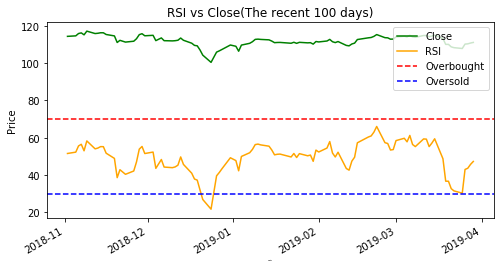

```python
# to slice the recent 100 days
Disney['Adj Close'][-100:].plot(figsize=(8,4),color='green')
Disney['RSI'][-100:].plot(color='orange')
# to draw the plot
plt.xlabel('Date',fontsize = 2)
plt.ylabel('Price')
plt.axhline(y=70, color='r', linestyle='--')
plt.axhline(y=30, color='b', linestyle='--')
plt.title('RSI vs Close(The recent 100 days)')
plt.legend(('Close','RSI','Overbought','Oversold'),loc='upper right')
plt.show()
```

From the graph, we can see that the trend of RSI and adj Close price is similar. During December 2018, there is an oversold period.

### Combining dataset

```python
DJI=pd.read_csv("DJI.csv")
NASDAQ=pd.read_csv("IXIC.csv")
SP=pd.read_csv("GSPC.csv")
DJI.set_index('Date',inplace = True)
NASDAQ.set_index('Date',inplace = True)
SP.set_index('Date',inplace = True)
```

```python
#Add RSI,NASDAQ,DJI,S&P500 to the dataset
Disney['NASDAQ']=NASDAQ['Adj Close']
Disney['DJI']=DJI['Adj Close']
Disney['S&P500']=SP['Adj Close']
```

```python
#more other variables
Disney['H-L'] = Disney['High'] - Disney['Low']
Disney['O-C'] = Disney['Close'] - Disney['Open']
Disney['Std_dev']= Disney['Close'].rolling(5).std()
Disney.head()
```

| Date | Open | High | Low | Close | Adj Close | Volume | 5 MA | 10 MA | 20 MA | EMA | RSI | NASDAQ | DJI | S&P500 | H-L | O-C | Std_dev |
| --- | --- | --- | --- | --- | --- | --- | --- | --- | --- | --- | --- | --- | --- | --- | --- | --- | --- |
| 2014-01-02 | 76.040001 | 76.500000 | 75.900002 | 76.269997 | 71.050354 | 5200900 | NaN | NaN | NaN | 75.814893 | NaN | 4143.069824 | 16441.349609 | 1831.979980 | 0.599998 | 0.229996 | NaN |
| 2014-01-03 | 76.300003 | 76.699997 | 76.010002 | 76.110001 | 70.901306 | 4060700 | NaN | NaN | NaN | 75.814893 | NaN | 4131.910156 | 16469.990234 | 1831.369995 | 0.689995 | -0.190002 | NaN |
| 2014-01-06 | 76.529999 | 76.839996 | 75.489998 | 75.820000 | 70.631157 | 6816200 | NaN | NaN | NaN | 75.814893 | NaN | 4113.680176 | 16425.099609 | 1826.770020 | 1.349998 | -0.709999 | NaN |
| 2014-01-07 | 76.120003 | 76.699997 | 75.900002 | 76.339996 | 71.115562 | 4494900 | NaN | NaN | NaN | 75.814893 | NaN | 4153.180176 | 16530.939453 | 1837.880005 | 0.799995 | 0.219993 | NaN |
| 2014-01-08 | 76.129997 | 76.279999 | 74.809998 | 75.220001 | 70.072197 | 10900300 | 75.951999 | NaN | NaN | 75.814893 | NaN | 4165.609863 | 16462.740234 | 1837.489990 | 1.470001 | -0.909996 | 0.455487 |

### ARIMA

Autoregressive Integrated Moving Average Model (ARIMA) is a model usually used in time series forecasting We took 5-year historical data as training data to fit our model. and use the first three months of 2019 to test

```python
#import packages for arima
from pyramid.arima import auto_arima
import pandas as pd
import numpy as np
from matplotlib import pyplot as plt
```

```python
#create dataframe just for LSTM
df=Disney
del df['Open']
#del df['Date']
del df['High']
del df['Low']
del df['Adj Close']
del df['Volume']
df.head()
```

```python
#Partition into train and test
train=df[:1259]
test=df[1259:]
#Get only close price
training =train['Close']
testing =test['Close']
```

```python
#train model
arima=auto_arima(training, start_p=1, start_q=1,max_p=4, max_q=4, start_P=0, seasonal=False,d=1, D=1, trace=True,error_action='ignore',suppress_warnings=True, stepwise=True)
arima.fit(training)
```

```
Fit ARIMA: order=(1, 1, 1); AIC=nan, BIC=nan, Fit time=nan seconds
Fit ARIMA: order=(0, 1, 0); AIC=4059.916, BIC=4070.191, Fit time=0.003 seconds
Fit ARIMA: order=(1, 1, 0); AIC=4061.630, BIC=4077.042, Fit time=0.018 seconds
Fit ARIMA: order=(0, 1, 1); AIC=4061.619, BIC=4077.031, Fit time=0.025 seconds
Total fit time: 0.117 seconds
```

```
ARIMA(callback=None, disp=0, maxiter=50, method=None, order=(0, 1, 0),
   out_of_sample_size=0, scoring='mse', scoring_args={},
   seasonal_order=None, solver='lbfgs', start_params=None,
   suppress_warnings=True, transparams=True, trend='c')
```

```python
#predict use test data
predict=arima.predict(n_periods=60)
predict = pd.DataFrame(predict,index = test.index,columns=['Prediction'])
```

```python
#calculate mse
mse=np.sqrt(np.mean(np.power((np.array(test['Close'])-np.array(predict['Prediction'])),2)))
mse
```

```
2.8102808335217264
```

```python
#summary of ARIMA model
print(arima.summary())
```

```
                             ARIMA Model Results
==============================================================================
Dep. Variable:                    D.y   No. Observations:                 1258
Model:                 ARIMA(0, 1, 0)   Log Likelihood               -2027.958
Method:                           css   S.D. of innovations              1.213
Date:                Wed, 03 Apr 2019   AIC                           4059.916
Time:                        20:31:23   BIC                           4070.191
Sample:                             1   HQIC                          4063.777

==============================================================================
                 coef    std err          z      P>|z|      [0.025      0.975]
------------------------------------------------------------------------------
const          0.0260      0.034      0.760      0.447      -0.041       0.093
==============================================================================
```

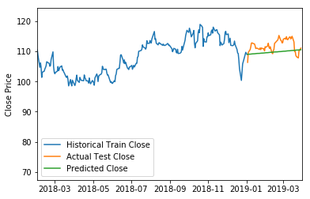

```python
#plot
plt.plot(train['Close'])
plt.plot(test['Close'])
plt.plot(predict['Prediction'])
plt.xlim('2018-02-01','2019-03-31')
plt.legend(('Historical Train Close', 'Actual Test Close', 'Predicted Close'))
plt.ylabel('Close Price')
```

### Neural Network Model

```python
#to determine independent variables and dependent variables
indep_v=["Open","High","Low","5 MA","10 MA","20 MA"]
Disney = Disney.dropna()
X = Disney[indep_v]
y = Disney["Close"]
#to split data into training set and test set
split = int(len(Disney)*0.8)
X_train, X_test, y_train, y_test = X[:split], X[split:], y[:split], y[split:]
X_train.head()
```

| Date | Open | High | Low | 5 MA | 10 MA | 20 MA |
| --- | --- | --- | --- | --- | --- | --- |
| 2014-01-30 | 72.089996 | 73.629997 | 72.000000 | 72.480000 | 73.489000 | 74.346999 |
| 2014-01-31 | 72.199997 | 73.320000 | 71.800003 | 72.458000 | 73.329000 | 74.164000 |
| 2014-02-03 | 72.660004 | 72.730003 | 69.849998 | 72.006000 | 72.930000 | 73.857999 |
| 2014-02-04 | 70.940002 | 71.250000 | 69.879997 | 71.640001 | 72.615000 | 73.619500 |
| 2014-02-05 | 72.050003 | 72.050003 | 70.370003 | 71.726001 | 72.260001 | 73.390500 |

```python
#to standardlize variables
from sklearn.preprocessing import StandardScaler
sc = StandardScaler()
X_train = sc.fit_transform(X_train) #Fit to data, then transform it.
X_test = sc.transform(X_test) #Perform standardization by centering and scaling.
```

```python
from keras.models import Sequential
from keras.layers import Dense
from keras.layers import Dropout
```

```python
#build neural network structure
model = Sequential()
model.add(Dense(units = 1024, activation = 'relu', input_dim = X.shape[1]))
model.add(Dense(units = 512,activation = 'relu'))
model.add(Dense(units = 256, activation = 'relu'))
model.add(Dense(units = 128,  activation = 'relu'))
model.add(Dense(units = 1, activation = 'linear'))
model.compile(optimizer = 'adam', loss = 'mean_squared_error', metrics = ['accuracy'])
model.fit(X_train, y_train, epochs = 100)
```

[output not shown]

```
<keras.callbacks.History at 0x268bf9e31d0>
```

```python
#show the prediction result
model.evaluate(X_test, y_test)
```

```
[1.3560409252460186, 0.0038461538461538464]
```

[figure not shown]

```python
#show the prediction result
closing_predict = model.predict(X_test)
plt.plot(range(260), y_test, color='g')
plt.plot(range(260), closing_predict, color='orange')
plt.xlabel('Date')
plt.ylabel('Price')
plt.title('prediction result vs. actual closing price')
plt.legend(('reality','prediction'))
plt.show()
```

### LSTM Model

LSTM are used in sequence prediction problems because LSTM can store past information that is important and forget the unimportant information

```python
#load packages for LSTM
from sklearn.preprocessing import MinMaxScaler
from keras.models import Sequential
from keras.layers import Dense, Dropout, LSTM
```

```python
#set date as index
Disney['Date']=pd.to_datetime(Disney.Date, format='%Y-%m-%d')
Disney.index = Disney['Date']
Disney.head()
#create dataframe just for LSTM
df=Disney
del df['Open']
del df['Date']
del df['High']
del df['Low']
del df['Adj Close']
del df['Volume']
df.head()
```

```python
#split train and test data
#create dataset to contain only the close price
dataset=df.values
#tran and test
train=dataset[0:1259,:]
valid=dataset[1259:,:]
```

```python
#scale dataset
scaler=MinMaxScaler(feature_range=(0,1))
scaled_data=scaler.fit_transform(dataset)
print(scaled_data)
```

```python
#convert dataset into x_train and y_train
x_train=[]#predictors
y_train=[]#target
for i in range(60,len(train)):
    x_train.append(scaled_data[i-60:i,0])
    y_train.append(scaled_data[i,0])

x_train, y_train = np.array(x_train), np.array(y_train)
#convert x_train from one list to a list contain each number as a list
x_train = np.reshape(x_train, (x_train.shape[0],x_train.shape[1],1))
```

```python
#fit LSTM
model = Sequential()
model.add(LSTM(units=50, return_sequences=True, input_shape=(x_train.shape[1],1)))
model.add(LSTM(units=50))
model.add(Dense(1))

model.compile(loss='mean_squared_error', optimizer='adam')
model.fit(x_train, y_train, epochs=1, batch_size=1, verbose=2)
```

[output not shown]

```
<keras.callbacks.History at 0x1a32417860>
```

```python
#predicting 111 values from 2018-10-4 to today, using past 60 from the train data
inputs = df[len(df) - len(valid) - 60:].values
inputs = inputs.reshape(-1,1)
inputs  = scaler.transform(inputs)#scale inputs

#X_test as 2019/1/2 to today
X_test = []
for i in range(60,inputs.shape[0]):
    X_test.append(inputs[i-60:i,0])
X_test = np.array(X_test)
X_test = np.reshape(X_test, (X_test.shape[0],X_test.shape[1],1))
#predicted closing price as 2019/1/2 to today
closing_price = model.predict(X_test)
closing_price = scaler.inverse_transform(closing_price)#convert scale to price
```

```python
#summary of the LSTM model
print(model.summary())
```

```
_________________________________________________________________
Layer (type)                 Output Shape              Param #
=================================================================
lstm_1 (LSTM)                (None, 60, 50)            10400
_________________________________________________________________
lstm_2 (LSTM)                (None, 50)                20200
_________________________________________________________________
dense_1 (Dense)              (None, 1)                 51
=================================================================
Total params: 30,651
Trainable params: 30,651
Non-trainable params: 0
_________________________________________________________________
None
```

```python
#calculate MSE
mse=np.sqrt(np.mean(np.power((valid-closing_price),2)))
mse
```

```
1.911304650899819
```

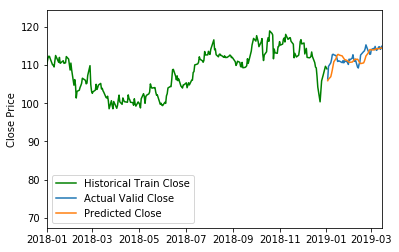

```python
#for plotting
import matplotlib.pyplot as plt

train = df[:1259]
valid = df[1259:]
valid['Predictions'] = closing_price#add column predictions as closing price
plt.plot(train['Close'], color='green')
plt.plot(valid[['Close','Predictions']])
plt.xlim('2018-01-01','2019-03-15')
plt.legend(('Historical Train Close', 'Actual Valid Close', 'Predicted Close'))
plt.ylabel('Close Price')
```

### SVM

```python
from sklearn import svm,preprocessing
from sklearn.linear_model import SGDRegressor
#dfsvm=Disney[['Close','Open','Volume','EMA','NASDAQ','DJI','S&P500','H-L','O-C']]
dfsvm=Disney[['Close','Open','EMA','NASDAQ','DJI','S&P500']]
dfsvm.head()
```

```python
#SVC
value = pd.Series(dfsvm['Close']-dfsvm['Open'],\
                         index=dfsvm.index)

#Calculate the value to show wheather today is up or down
value[value>0]=1
value[value<=0]=0
dfsvc = dfsvm
names=dfsvc.columns
n=dfsvc.index
scaler = preprocessing.StandardScaler()
# Fit data on the scaler object
dfsvc= scaler.fit_transform(dfsvc)
dfsvc=pd.DataFrame(dfsvc,columns=names,index=n)
dfsvc['Value']=value
#dfsvc['Value']=dfsvc['Value'].shift(-1).fillna(0)
dfsvc['Value']=dfsvc['Value']
dfsvc[1258:].head()
```

| Date | Close | Open | EMA | NASDAQ | DJI | S&P500 | Value |
| --- | --- | --- | --- | --- | --- | --- | --- |
| 2019-01-02 | 0.712756 | 0.627158 | 0.551522 | 0.846321 | 0.974906 | 0.724471 | 1.0 |
| 2019-01-03 | 0.464361 | 0.662847 | 0.593244 | 0.673776 | 0.779091 | 0.530915 | 0.0 |
| 2019-01-04 | 0.772973 | 0.612131 | 0.656168 | 0.908472 | 1.000693 | 0.792717 | 1.0 |
| 2019-01-07 | 0.862357 | 0.797151 | 0.717945 | 0.980588 | 1.029824 | 0.848005 | 1.0 |
| 2019-01-08 | 0.943274 | 0.974657 | 0.718485 | 1.043259 | 1.105804 | 0.925004 | 0.0 |

```python
#2014.1.1-2018.12.31 has 1258 recordings, used as training data
train=1258
L=len(dfsvc)
total_predict_data=L-train
predict_result=np.zeros(61)

#drop the DV
df_CB_X=dfsvc.drop(['Value'],axis=1)
correct = 0
train_original=train
while train<L:
    #use the historical 1258 rows data
    Data_train=df_CB_X[train-train_original:train]
    value_train = dfsvc['Value'][train-train_original:train]
    Data_predict=df_CB_X[train:train+1]
    value_real = dfsvc['Value'][train:train+1]

    #classifier = svm.SVC(C=100, kernel='poly',gamma='scale')
    classifier = svm.SVC(C=1000,kernel='linear',gamma='scale')
    #classifier = svm.SVC(C=1000,kernel='rbf',gamma='scale')
    classifier.fit(Data_train,value_train)
    value_predict=classifier.predict(Data_predict)
    predict_result[train-1258]=value_predict
    if(value_real[0]==int(value_predict)):
        correct=correct+1
    train = train+1
correct=correct*100/total_predict_data
print("Correct=%.2f%%"%correct)
```

```
Correct=100.00%
```

Both model svm.SVC(C=100, kernel='poly',gamma='scale') and svm.SVC(C=1000,kernel='linear',gamma='scale') reach 100% accuracy, other models also reach accuracy of more than 95%.

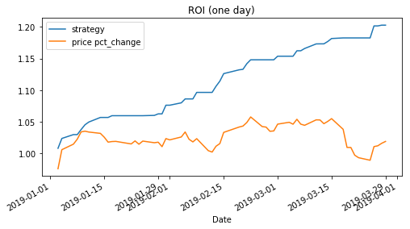

```python
svc_result = pd.DataFrame(predict_result,index=dfsvm.index[1258:])
svc_result.columns = ['position']
svc_result['real']=value[1258:]
svc_result['open'] = dfsvm['Open'][1258:]
svc_result['close'] = dfsvm['Close'][1258:]
svc_result['PL'] = np.where(svc_result['position'] == 1, (svc_result['close'] - svc_result['open']) / svc_result['open'], 0)
svc_result['strategy'] = (svc_result['PL'] + 1).cumprod()
svc_result['price pct_change'] = (svc_result['close'].pct_change() + 1).cumprod()
svc_result[['strategy', 'price pct_change']].dropna().plot(figsize=(8,4),title='ROI (one day)')
```

```python
#SVR
for i in range(1, 21, 1):
    dfsvm['Close-' + str(i) + 'd'] = dfsvm['Close'].shift(i)

dfsvr = dfsvm.iloc[20:]
dfsvr = dfsvr.iloc[:, ::-1]
names=dfsvr.columns
n=dfsvr.index
scaler = preprocessing.StandardScaler()
# Fit data on the scaler object
dfsvr= scaler.fit_transform(dfsvr.drop('Close',axis=1))
dfsvr=pd.DataFrame(dfsvr,index=n)
dfsvr.head()
```

Add last 20 days close price to the model

```python
days = 1238

#train data
fit_train = dfsvr[:days].values

#to predict today's closs price given the open price
real_train = pd.Series(dfsvm['Close'][20:days+20].values)

#to predict next day's price
#real_train = pd.Series(dfsvr['Close'].shift(-1)[:days].values)

#test
fit_test = dfsvr[days:].values
#real_test = pd.Series(dfsvr['Close'].shift(-1)[days:].values,index=dfsvr.index[1238:])
real_test = pd.Series(dfsvm['Close'][days+20:].values,index=dfsvr.index[1238:])
```

```python
predict_svm = SGDRegressor(loss='epsilon_insensitive',max_iter=100000,tol=None)
#predict_svm = svm.SVR(kernel='linear', C=1e3,cache_size=7000)
#predict_svm = svm.LinearSVR(C=1e2)
predict_svm.fit(fit_train, real_train)
```

```
SGDRegressor(alpha=0.0001, average=False, early_stopping=False, epsilon=0.1,
       eta0=0.01, fit_intercept=True, l1_ratio=0.15,
       learning_rate='invscaling', loss='epsilon_insensitive',
       max_iter=100000, n_iter=None, n_iter_no_change=5, penalty='l2',
       power_t=0.25, random_state=None, shuffle=True, tol=None,
       validation_fraction=0.1, verbose=0, warm_start=False)
```

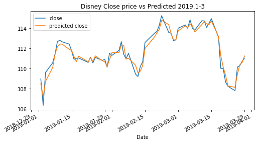

```python
p_test = predict_svm.predict(fit_test)

svr_result = pd.DataFrame(dfsvm['Close'][1258:],index=dfsvm.index[1258:])
#predict next days close
#svr_result = pd.DataFrame(dfsvr['Close'][1238:].shift(-1),index=dfsvr.index[1238:])
svr_result.columns = ['close']
svr_result['predicted close'] = p_test
svr_result.plot(figsize=(8,4),title='Disney Close price vs Predicted 2019.1-3')
```

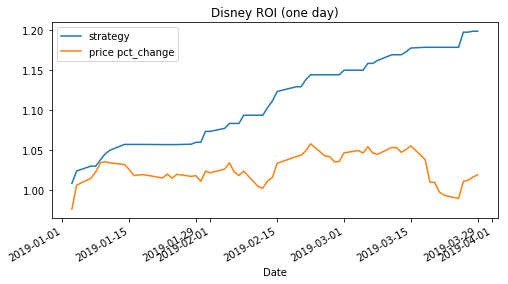

```python
#ROI-SVR
#assuming no trading costs
svr_result['open'] = dfsvm['Open'][1258:]
svr_result['position'] = np.where(svr_result['predicted close'] > svr_result['open'], 1, 0)
svr_result['PL'] = np.where(svr_result['position'] == 1, (svr_result['close'] - svr_result['open']) / svr_result['open'], 0)
svr_result['strategy'] = (svr_result['PL'] + 1).cumprod()
svr_result['price pct_change'] = (svr_result['close'].pct_change() + 1).cumprod()
svr_result[['strategy', 'price pct_change']].dropna().plot(figsize=(8,4),title='Disney ROI (one day)')
```

# Part 2 Test the Best Model on Other Two Companies (Apple and Ford)

### Apple

```python
#Test on the other two companies
import pandas_datareader.data as pdr
from datetime import datetime
start = datetime(2014,1,1)
end = datetime(2019,3,29)
apple = pdr.get_data_yahoo("AAPL", start=start, end=end)
ford = pdr.get_data_yahoo("F", start=start, end=end)
```

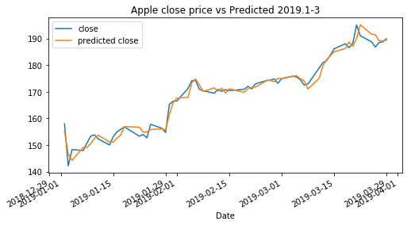

```python
appl=apple
appl['NASDAQ']=NASDAQ['Open']
appl['DJI']=DJI['Open']
appl['S&P500']=SP['Open']
appl['EMA']=EMA(appl['Open'],5)
appl=appl.drop('High',axis=1)
appl=appl.drop('Low',axis=1)
appl=appl.drop('Volume',axis=1)
appl=appl.drop('Adj Close',axis=1)
for i in range(1, 21, 1):
    appl['Close-' + str(i) + 'd'] = appl['Close'].shift(i)
appl = appl.iloc[20:]
appl = appl.iloc[:, ::-1]
names=appl.columns
n=appl.index
# Fit data on the scaler object
appl= scaler.fit_transform(appl.drop('Close',axis=1))
appl=pd.DataFrame(appl)

#train data
fit_train2 = appl[:days].values
real_train2 = pd.Series(apple['Close'][20:days+20].values)

#test data
fit_test2 = appl[days:].values

predict_svm.fit(fit_train2, real_train2)
p_test2 = predict_svm.predict(fit_test2)
appl_result = pd.DataFrame(apple['Close'][1258:],index=apple.index[1258:])
appl_result.columns = ['close']
appl_result['predicted close'] = p_test2
appl_result.plot(figsize=(8,4),title='Apple close price vs Predicted 2019.1-3')
```

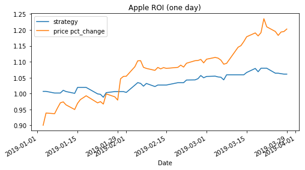

```python
appl_result['open'] = apple['Open'][1258:]
appl_result['position'] = np.where(appl_result['predicted close'] > appl_result['open'], 1, 0)
appl_result['PL'] = np.where(appl_result['position'] == 1, (appl_result['close'] - appl_result['open']) / appl_result['open'], 0)
appl_result['strategy'] = (appl_result['PL'] + 1).cumprod()
appl_result['price pct_change'] = (appl_result['close'].pct_change() + 1).cumprod()
appl_result[['strategy', 'price pct_change']].dropna().plot(figsize=(8,4),title='Apple ROI (one day)')
```

### Ford

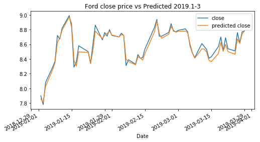

```python
f=ford
f['NASDAQ']=NASDAQ['Open']
f['DJI']=DJI['Open']
f['S&P500']=SP['Open']
f['EMA']=EMA(f['Close'],5)
f=f.drop('High',axis=1)
f=f.drop('Low',axis=1)
f=f.drop('Volume',axis=1)
f=f.drop('Open',axis=1)
for i in range(1, 21, 1):
    f['Close-' + str(i) + 'd'] = f['Close'].shift(i)
f = f.iloc[20:]
f = f.iloc[:, ::-1]
names=f.columns
n=f.index
# Fit data on the scaler object
f= scaler.fit_transform(f.drop('Close',axis=1))
f=pd.DataFrame(f,index=n)

#train data
fit_train3 = f[:days].values
real_train3 = pd.Series(ford['Close'][20:days+20].values)

#test data
fit_test3 = f[days:].values

#predict_svm3 = SGDRegressor(loss='epsilon_insensitive')
predict_svm.fit(fit_train3, real_train3)
p_test3 = predict_svm.predict(fit_test3)

f_result = pd.DataFrame(ford['Close'][1258:],index=ford.index[1258:])
f_result.columns = ['close']
f_result['predicted close'] = p_test3
f_result.plot(figsize=(8,4),title='Ford close price vs Predicted 2019.1-3')
```

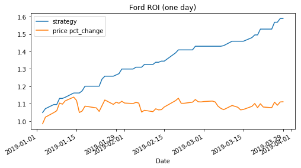

```python
f_result['open'] = ford['Open'][1258:]
f_result['position'] = np.where(f_result['predicted close'] > f_result['open'], 1, 0)
f_result['PL'] = np.where(f_result['position'] == 1, (f_result['close'] - f_result['open']) / f_result['open'], 0)
f_result['strategy'] = (f_result['PL'] + 1).cumprod()
f_result['price pct_change'] = (f_result['close'].pct_change() + 1).cumprod()
f_result[['strategy', 'price pct_change']].dropna().plot(figsize=(8,4),title='Ford ROI (one day)')
```

Fords ROI reachs near 60%. The total ROI in this part is calculated by the cumulative product of each previous day's ROI, the real ROI may not that high.

# Part 3 News and Comments

## Scrape Tweets

```python
#change working directory
import os
os.chdir("D:\python\\UMDpythonGroup")
```

```python
import tweepy
import csv
import json
```

```python
# credential data is hidden
with open('twitter_credentials.json') as cred_data:
    info = json.load(cred_data)
    consumer_key = info['CONSUMER_KEY']
    consumer_secret = info['CONSUMER_SECRET']
    access_token  = info['ACCESS_KEY']
    access_token_secret  = info['ACCESS_SECRET']

class PrintListener(tweepy.StreamListener):
    def on_data(self, data):
        # Decode the JSON data
        tweet = json.loads(data)

        user_name=str(tweet['user']['screen_name'])
        text=str(tweet['text'].encode('ascii', 'ignore'))
        time=str(tweet['created_at'])
        content=[user_name,text,time]
        print(content)
        writer.writerow(content)
        #print('@%s: %s,%s' % (tweet['user']['screen_name'], tweet['text'].encode('ascii', 'ignore'),tweet['created_at']))

    def on_error(self, status):
        print(status)


if __name__ == '__main__':
    """this model should be stopped by manual, otherwise, it will run continuously"""

    # to extract to .csv file
    with open('Apple_tweets.csv', 'w', encoding='utf8') as f:
        writer = csv.writer(f)
        writer.writerow(['user', 'text', 'time'])

        listener = PrintListener()

        # Show system message
        print('I will now print Tweets containing "Apple"! ==>')

        # Authenticate
        auth = tweepy.OAuthHandler(consumer_key, consumer_secret)
        auth.set_access_token(access_token, access_token_secret)

        # Connect the stream to our listener
        stream = tweepy.Stream(auth, listener)
        stream.filter(track=['Apple'])
```

We scraped more than 2000 tweets contains feature word 'Apple', and save the result into a .csv file for following steps.

## Scrape News from Reuters

```python
import re
import pandas as pd
from bs4 import BeautifulSoup
from urllib.request import Request, urlopen
import csv
import time
import random
```

```python
from selenium import webdriver

url='https://www.reuters.com/search/news?blob=apple'
driver = webdriver.Chrome('E:\chromedriver\chromedriver.exe')
driver.get(url)

#for Reuters use dynamical loading, to turn the page.
page_max=20
for i in range(20):
    button = driver.find_elements_by_class_name('search-result-more-txt')
    button[0].click()
    time.sleep(2)
```

```python
# to get all news models
soup = BeautifulSoup(driver.page_source, 'lxml')
paragraph=soup.find_all('h3')
len(paragraph)
```

```python
# to get all the news url link, for further scrape their content
link=[]
pat='<a href=\".+\"'
for item in paragraph:
    m = re.search(pat,str(item))
    href=m.group()
    link.append(href[9:-1])
len(link)
```

```python
import os
os.chdir("D:\python\\UMDpythonGroup\\apple")
```

```python
apple_news=dict()
```

```python
# to get content of each news
for i in range(len(link)):
    item=link[i]
    time.sleep(random.randrange(5,15))
    # the domain url
    domain='https://www.reuters.com/'
    req = Request(domain+item, headers={'User-Agent': 'Mozilla/5.0'})
    webpage = urlopen(req).read()
    soup = BeautifulSoup(webpage, 'html.parser')

    # details to store in .csv
    title=str(soup.find_all('h1'))[36:-6]
    time_stamp=str(soup.find_all('div')[50])[32:-6]
    apple_news[i]=[title,time_stamp]

    # content of news
    paragraph=soup.find_all('p')[1:-2]
    content=[]
    for p in paragraph:
        content.append(str(p)[3:-4])
    # to export to .txt file
    with open(str(i)+'.txt','w') as f:
        for p in paragraph:
            f.write("%s\n" % str(p)[3:-4])
```

```python
# the total list of news, containing ID, title, time
with open('apple_news.csv', 'w') as csv_file:
    writer = csv.writer(csv_file)
    for key, value in apple_news.items():
        writer.writerow([key, value[0],value[1]])
```

Downloaded more than 200 news and did text analysis on them.

## Sentiment Analysis

### Based on News Titles

```python
colnames=['1','Title','Date']
news=pd.read_csv('apple_news.csv',encoding = "ISO-8859-1",names=colnames)
news=news.drop('1',axis=1)
news.head()
```

|  | Title | Date |
| --- | --- | --- |
| 0 | Apple's iPhone struggles unravel ambitions of ... | March 22, 2019 / 6:11 AM / a month ago |
| 1 | BUZZ-IQE: One good Apple helps the bunch | April 30, 2019 / 1:05 PM / in 5 days |
| 2 | Apple wins reversal in University of Wisconsin... | September 28, 2018 / 1:54 PM / 7 months ago |
| 3 | Apple's warning a bad omen for Wall Street bulls | January 3, 2019 / 12:43 AM / 4 months ago |
| 4 | Apple agrees to pay back-taxes to French autho... | February 5, 2019 / 9:48 AM / 3 months ago |

```python
import re
pat = '(\w+\s\d+[,]\s\d{4})'

#Extract date in the second column
for i in range(len(news['Date'])):
    m = re.match(pat,news['Date'].iloc[i])
    news['Date'].iloc[i]=m.group()
pat1='\s'
news['Date']=news['Date'].str.replace(pat1,'-')
news['Date']=news['Date'].str.replace(',','')
news.tail()
```

```python
news['Date']=pd.to_datetime(news.Date, format='%B-%d-%Y')
news.set_index('Date',inplace=True)
news.drop_duplicates(keep = False, inplace = True)
news=news.sort_index()
news.tail()
```

| Date | Title |
| --- | --- |
| 2019-04-30 | Breakingviews - Apples old age beats Googles... |
| 2019-04-30 | Apple optimistic as accessories, iPhone price ... |
| 2019-04-30 | Apple optimistic on sales as iPhone price cuts... |
| 2019-05-01 | Apple results beat sets eyes back on $1 trillion |
| 2019-05-02 | Breakingviews - Viewsroom: Apple versus Alphabet |

```python
import nltk
from nltk.sentiment.vader import SentimentIntensityAnalyzer as SIA
nltk.download('vader_lexicon')
sia = SIA()
results=[]
pol_score=[]
for line in news['Title']:
    pol_score = sia.polarity_scores(line)
    pol_score['headline'] = line
    results.append(pol_score)
```

```python
df = pd.DataFrame.from_records(results)
#Let's create a positive label of 1 if the compound is greater than 0.2, and a label of -1 if compound is less than -0.2. Everything else will be 0.
df['label'] = 0
df.loc[df['compound'] > 0.2, 'label'] = 1
df.loc[df['compound'] < -0.2, 'label'] = -1
df.head()
```

```python
df.index=news.index
news['Sentiment']=df['compound']
news['label']=df['label']
#some date may have more than 1 records, group them and calculate the average of the sentiment
sen=news.groupby('Date')['Sentiment'].mean()
sen=pd.DataFrame(sen)
sen['label']=news.groupby('Date')['label'].mean()
```

```python
#get the APPLE stock data
start = datetime(2018,9,1)
end = datetime(2019,5,6)
appl = pdr.get_data_yahoo("AAPL", start=start, end=end)
```

```python
#DatetimeIndex(['2018-10-14', '2018-11-25', '2019-01-12', '2019-01-12'], dtype='datetime64[ns]', name='Date', freq=None) not in index
#In these 4 days, stock market is closed, delete these records.
sen.drop([sen.index[3],sen.index[14],sen.index[26]],inplace=True)
```

```python
List=sen.index.tolist()
app=appl[appl.index.isin(List)]
sen.index=app.index
sen['Open']=app['Open']
sen['Close']=app['Close']
sen['High']=app['High']
sen['Low']=app['Low']
sen['C-O']=sen['Close']-sen['Open']
sen['H-L']=sen['High']-sen['Low']
sen.head()
```

| Date | Sentiment | label | Open | Close | High | Low | C-O | H-L |
| --- | --- | --- | --- | --- | --- | --- | --- | --- |
| 2018-09-07 | 0.0000 | 0.0 | 221.850006 | 221.300003 | 225.369995 | 220.710007 | -0.550003 | 4.659988 |
| 2018-09-28 | 0.5719 | 1.0 | 224.789993 | 225.740005 | 225.839996 | 224.020004 | 0.950012 | 1.819992 |
| 2018-10-11 | -0.4939 | -1.0 | 214.520004 | 214.449997 | 219.500000 | 212.320007 | -0.070007 | 7.179993 |
| 2018-10-17 | 0.0258 | 0.0 | 222.300003 | 221.190002 | 222.639999 | 219.339996 | -1.110001 | 3.300003 |
| 2018-10-19 | 0.0000 | 0.0 | 218.059998 | 219.309998 | 221.259995 | 217.429993 | 1.250000 | 3.830002 |

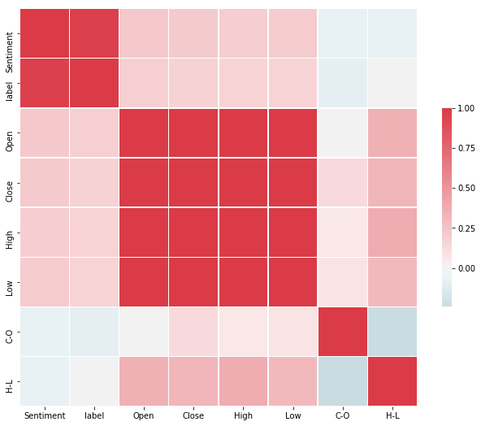

```python
import seaborn as sns
corr=sen.corr()

# Set up the matplotlib figure
f, ax = plt.subplots(figsize=(11, 9))

# Generate a custom diverging colormap
cmap = sns.diverging_palette(220, 10, as_cmap=True)

# Draw the heatmap with the mask and correct aspect ratio
sns.heatmap(corr, cmap=cmap, center=0,
            square=True, linewidths=.5, cbar_kws={"shrink": .5})
```

There is no significant correlation between Sentiment and Close-Open or High-Low.

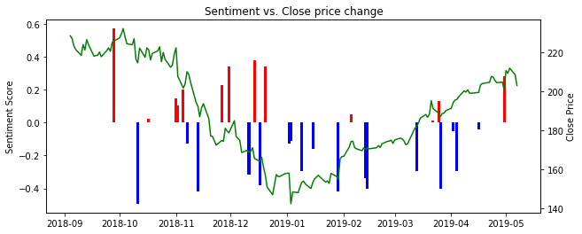

```python
appl.loc[sen.index,'Sentiment']=sen['Sentiment']
appl['Sentiment']=appl['Sentiment'].fillna(0)
plt.figure(figsize=(10,4))
width = 1.5
colormat=np.where(appl['Sentiment']>0, 'r','b')
plt.bar(appl.index,appl['Sentiment'], width, color=colormat)
plt.ylabel('Sentiment Score')
axes2 = plt.twinx()
axes2.plot(appl.index,appl['Close'], color='g')
axes2.set_ylabel('Close Price')
plt.title('Sentiment vs. Close price change')
plt.show()
```

From this figure, we can also see that there is no connection between the News and the stock price. During 2019-11 to 2019-04, Apple stock has risen a lot, while there is much more negative news during this period.

### Based on News Content

```python
%pylab inline
import requests, re
import pandas as pd
import seaborn as sns
import nltk

import string, itertools
from collections import Counter, defaultdict
from nltk.text import Text
from nltk.probability import FreqDist
from nltk.tokenize import word_tokenize, sent_tokenize, regexp_tokenize
from nltk.corpus import stopwords
from nltk.stem import PorterStemmer, WordNetLemmatizer
from wordcloud import WordCloud
from gensim.corpora.dictionary import Dictionary
from gensim.models.tfidfmodel import TfidfModel
from sklearn.cluster import KMeans
```

```python
#read the news folder
apple=[]
path='D:\python\\UMDpythonGroup\\apple\\'
for i in range(209):
    try:
        filename=path+str(i)+'.txt'
        f=open(filename,'rb').read().splitlines()
        apple.append(f)
    except:
        print('')
```

```python
#list of lists to list
apple=list(itertools.chain.from_iterable(apple))
```

```python
#convert list to lowercase string
strapple=''
for i in apple:
    strapple=strapple+str(i.lower())
```

```python
strapple
```

```
'b\'(reuters) - apple inc launched apple arcade on monday, the company\\x92s game subscription service for mobile devices, desktop computers and \\x93living room\\x94 devices. \'b\'the iphone maker said it was working with walt disney co, sega and annapurna interactive on the new game service, which…
```

We can see from here, there are many unnecessary punctuation exsists due to the character type of the text file and the remaining links from scraping. Also, there are high frequency meaningless words like 'Reuters' and the authors name who published the news. These can't be filtered from dictionary of stopwords, so we have to mannually clean them. The following steps are the text cleaning.

```python
#remove all unnecessary punctuation
strapple = re.sub('[-$.<()>]', '', strapple)
strapple = re.sub(";'b\'", '', strapple)
strapple=strapple.replace("\\",'')
strapple=strapple.replace('x93','')
strapple=strapple.replace('x92','')
strapple=strapple.replace('x94','')
strapple=strapple.replace('x96','')
strapple=strapple.replace("b\'",'')
strapple=strapple.replace("''",'')
strapple=strapple.replace("'",'')
strapple=strapple.replace(',','')
strapple=strapple.replace(';','')
strapple=strapple.replace('class="attribution_content"','')
strapple=strapple.replace('href="','')
strapple=strapple.replace('://','')
strapple=strapple.replace('/','')
```

```python
# Word tokenization
applewords=word_tokenize(strapple)
# Filter stop words from tokenized words
applewords=[appleword for appleword in applewords if appleword not in stopwords.words('english')]
# Stopwords for apple ONLY
applestopword=['reuters','said','symbol','stephen','nellis','financestocksoverview','reporting','span','id','would','also']
# Filter stop words from tokenized words
applewords=[appleword for appleword in applewords if appleword not in applestopword]
print(applewords)
```

We repeated removing unnecessary punctuation and word filtering stopwords many times by manually removing more punctuation and adding more stopwords to the dictionary in order to make sure there is no meaningless words with high frequency.

```python
# Stemming
ps = PorterStemmer()
print([ps.stem(appleword) for appleword in applewords])
```

```python
# Lemmatizataion
lmtzr = WordNetLemmatizer()
applewords = [lmtzr.lemmatize(appleword) for appleword in applewords]
print(applewords)
```

The existing URLs caused a lot of problem so that there are unnecessary punctuation appear again.

```python
#remove''
for index, item in enumerate(applewords):
    if (item =="''"):
        applewords.remove(applewords[index])
```

We count words frequency and filter the top 20 words to not only see the words with high frequency, but also detect existing unnecessary punctuation and words.

```python
# Counter top 20 words in freq
applecommwords = Counter(applewords)
applecommwords.most_common(20)
```

```
[('apple', 1953),
 ('iphone', 438),
 ('company', 404),
 ('inc', 350),
 ('qualcomm', 345),
 ('service', 330),
 ('year', 276),
 ('sale', 260),
 ('chip', 246),
 ('percent', 238),
 ('billion', 236),
 ('new', 208),
 ('phone', 189),
 ('data', 188),
 ('patent', 186),
 ('iphones', 185),
 ('market', 183),
 ('editing', 178),
 ('user', 166),
 ('price', 163)]
```

```python
# FreqDist
applecommwordsfd = FreqDist(Text(applewords))
applecommwordsfd.most_common(20)
```

```
[('apple', 1953),
 ('iphone', 438),
 ('company', 404),
 ('inc', 350),
 ('qualcomm', 345),
 ('service', 330),
 ('year', 276),
 ('sale', 260),
 ('chip', 246),
 ('percent', 238),
 ('billion', 236),
 ('new', 208),
 ('phone', 189),
 ('data', 188),
 ('patent', 186),
 ('iphones', 185),
 ('market', 183),
 ('editing', 178),
 ('user', 166),
 ('price', 163)]
```

```python
# Tabulate
applecommwordsfd.tabulate(5)
```

```
   apple   iphone  company      inc qualcomm
    1953      438      404      350      345
```

```python
# Total samples and unique words
print('Total samples', applecommwordsfd.N())
print('Unique words', applecommwordsfd.B())
```

```
Total samples 43875
Unique words 5170
```

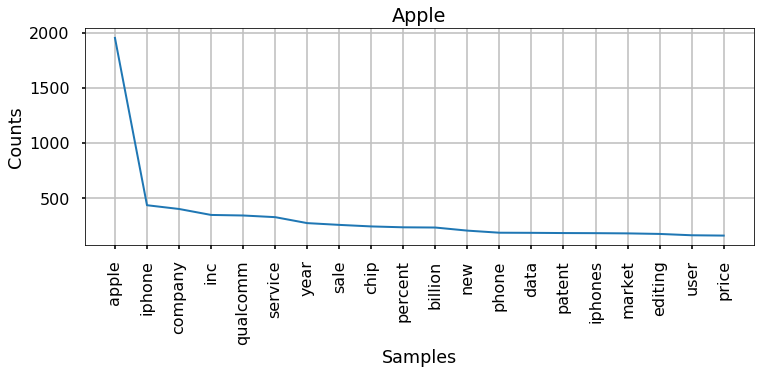

```python
# Visualize frequency of most common words (top 20)
with plt.style.context('seaborn-poster'):
    plt.figure(figsize=(12,4))
    applecommwordsfd.plot(20, title='Apple')
```

From the chart above and the word cloud we can see that news content about apple will mainly contain iphone, qualcomm, service and etc.

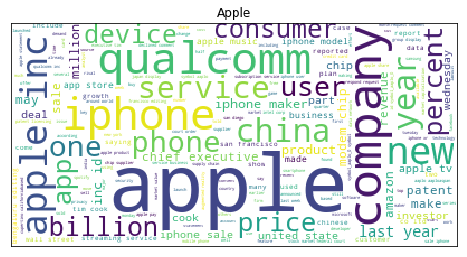

```python
# Word Cloud
applewc = WordCloud(background_color='white').generate(' '.join(applewords))
plt.figure(figsize=(8,8))
plt.xticks([])
plt.yticks([])
plt.imshow(applewc)
plt.title('Apple');
```